# Founders Circadian Rhythm Fibroblast Data: Heritability and Plotting

Michael C. Saul (michael.saul [at] jax.org)

# 1 Background

## 1.1 Motivation

### 1.1.1 Purpose of analysis

This analysis is performed to process the circadian rhythm amplitude data and calculate:

1. Heritability
2. Strain-by-sex means and standard errors for plotting

**These data were collected by Sam Moon-Kim.** The preprocessing script `circadian_fibroblastmport_preprocess.Rmd` was used to filter the data to only those data requiring reporting.

# 2 Analysis

## 2.1 Setup

### 2.1.1 Working directory

All chunks will run in the working folder for this experiment.

```r
script_root_dir = "~/Downloads/founders_heritability/"
knitr::opts_knit$set(root.dir = script_root_dir)
```

Getting current date

```r
current_date = format(Sys.time(),"%Y-%m-%d")
```

### 2.1.2 R libraries

Calling R libraries necessary for this analysis.

```r
library("tidyverse")
```

```r
library("lubridate")
library("cowplot")
library("MASS")
library("ggbeeswarm")
```

## 2.2 Importing data

## 2.3 Importing and displaying raw fibroblast amplitude data

Getting data from the filtering script.

```r
fibroblast_amplitude = readRDS(paste(script_root_dir, "data/circadian_amplitude_data_preprocessed_2019-09-04.RDS", sep = ""))
```

Displaying raw data.

```r
fibroblast_amplitude
```

|  | Subject | Culture | Strain | Sex | Cohort | StartYear | StartMonth | StartDay | EndYear | EndMonth | EndDay | Amplitude |
| --- | --- | --- | --- | --- | --- | --- | --- | --- | --- | --- | --- | --- |
| A617_1 | A617 | 1 | 129S1/SvImJ | Female | 2nd cohort | 2017 | 12 | 24 | 2017 | 12 | 29 | 518.120 |
| A617_2 | A617 | 2 | 129S1/SvImJ | Female | 2nd cohort | 2017 | 12 | 24 | 2017 | 12 | 29 | 431.993 |
| A617_3 | A617 | 3 | 129S1/SvImJ | Female | 2nd cohort | 2017 | 12 | 24 | 2017 | 12 | 29 | 849.246 |
| A617_4 | A617 | 4 | 129S1/SvImJ | Female | 2nd cohort | 2017 | 12 | 24 | 2017 | 12 | 29 | 694.699 |
| A618_1 | A618 | 1 | 129S1/SvImJ | Female | 2nd cohort | 2017 | 12 | 24 | 2017 | 12 | 29 | 479.919 |
| A618_2 | A618 | 2 | 129S1/SvImJ | Female | 2nd cohort | 2017 | 12 | 24 | 2017 | 12 | 29 | 303.095 |
| A618_3 | A618 | 3 | 129S1/SvImJ | Female | 2nd cohort | 2017 | 12 | 24 | 2017 | 12 | 29 | 487.407 |
| A618_4 | A618 | 4 | 129S1/SvImJ | Female | 2nd cohort | 2017 | 12 | 24 | 2017 | 12 | 29 | 643.522 |
| A5149_1 | A5149 | 1 | 129S1/SvImJ | Female | 4th cohort | 2018 | 12 | 20 | 2018 | 12 | 25 | 181.799 |
| A5149_2 | A5149 | 2 | 129S1/SvImJ | Female | 4th cohort | 2018 | 12 | 20 | 2018 | 12 | 25 | 149.805 |

[output cut: 195 more lines]

Getting the amplitude means and using these for heritability calculations.

```r
fibroblast_amplitude_mean = fibroblast_amplitude %>%
  group_by(Subject) %>%
  summarize(Strain = unique(Strain),
            Sex = unique(Sex),
            Cohort = unique(Cohort),
            Amplitude_Mean = mean(Amplitude))
fibroblast_amplitude_mean = as.data.frame(fibroblast_amplitude_mean)
```

Getting founders strain key

```r
founders_key = readRDS("~/Desktop/cc_do_founders_key.RDS")
row.names(founders_key) = founders_key$strain
```

### 2.3.1 Fitting ANOVA model for fibroblast data

Looking at the residuals of the simplest model first.

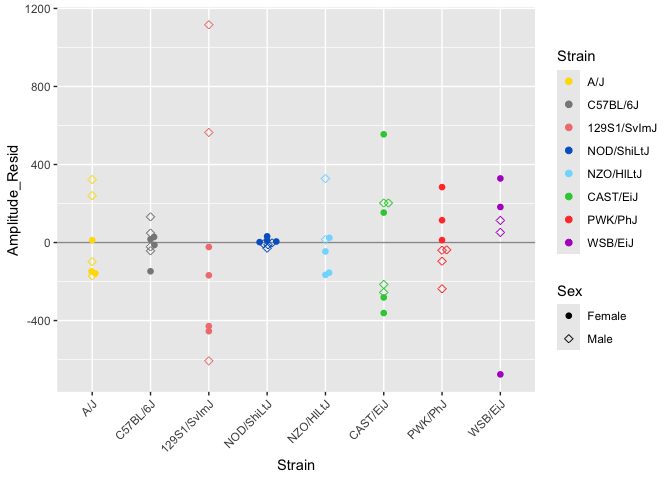

```r
fibroblast_amplitude_resid = fibroblast_amplitude_mean
fibroblast_amplitude_resid$Amplitude_Resid = resid(lm(Amplitude_Mean ~ Strain, data = fibroblast_amplitude_resid))
fibroblast_amplitude_resid$Strain = factor(fibroblast_amplitude_resid$Strain,
                                           levels = founders_key$strain,
                                           ordered = TRUE)

ggplot(data = fibroblast_amplitude_resid, aes(x = Strain, y = Amplitude_Resid, color = Strain, shape = Sex)) +
  geom_hline(yintercept = 0, col = "#999999") +
  geom_beeswarm(size = 2) +
  scale_color_manual(values = founders_key$collaborative_cross_color_broman) +
  theme(axis.text.x = element_text(angle = 45, hjust = 1)) +
  scale_shape_manual(values = c(16,23))
```

The residuals indicate heteroscedasticity – especially comparing 129 to NOD. Doing Box-Cox to see if a transform will help.

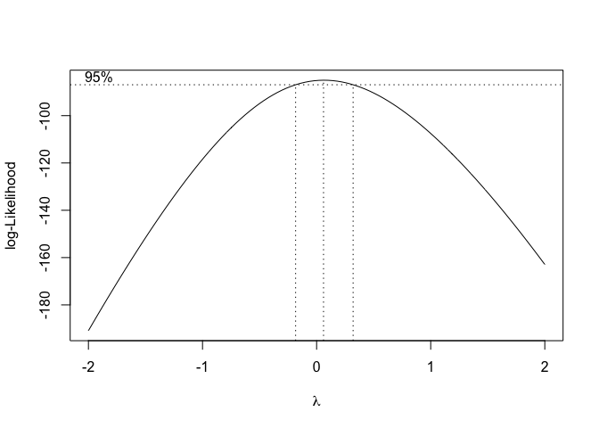

```r
boxcox(lm(Amplitude_Mean ~ Strain, data = fibroblast_amplitude_resid))
```

The Box-Cox log-likelihood is highest at 0, which implies that a log-transform will be advantageous.

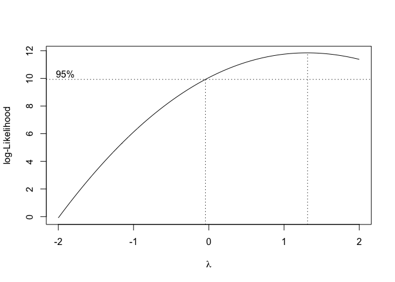

```r
boxcox(lm(log10(Amplitude_Mean) ~ Strain, data = fibroblast_amplitude_resid))
```

The Box-Cox is centered closer to 1. Plotting residuals.

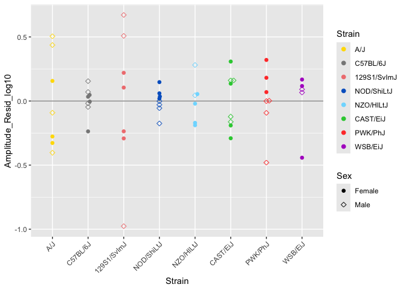

```r
fibroblast_amplitude_resid$Amplitude_Resid_log10 = resid(lm(log10(Amplitude_Mean) ~ Strain, data = fibroblast_amplitude_resid))

ggplot(data = fibroblast_amplitude_resid, aes(x = Strain, y = Amplitude_Resid_log10, color = Strain, shape = Sex)) +
  geom_hline(yintercept = 0, col = "#999999") +
  geom_beeswarm(size = 2) +
  scale_color_manual(values = founders_key$collaborative_cross_color_broman) +
  theme(axis.text.x = element_text(angle = 45, hjust = 1)) +
  scale_shape_manual(values = c(16,23))
```

There still appears to be some heteroscedasticity, but to within the tolerance of a linear model. This looks good. Comparing AICs for different possible models.

```r
AICs = c()
AICs["AIC_inter"] = AIC(lm(log10(Amplitude_Mean) ~ Cohort + Strain + Sex + Strain:Sex, data = fibroblast_amplitude_mean))
AICs["AIC_nointer"] = AIC(lm(log10(Amplitude_Mean) ~ Cohort + Strain + Sex, data = fibroblast_amplitude_mean))
AICs["AIC_nosex"] = AIC(lm(log10(Amplitude_Mean) ~ Cohort + Strain, data = fibroblast_amplitude_mean))
AICs["AIC_nocohort"] = AIC(lm(log10(Amplitude_Mean) ~ Strain, data = fibroblast_amplitude_mean))
AICs["AIC_nostrain"] = AIC(lm(log10(Amplitude_Mean) ~ Cohort, data = fibroblast_amplitude_mean))

AICs
```

```
##    AIC_inter  AIC_nointer    AIC_nosex AIC_nocohort AIC_nostrain
##     34.75357     27.90983     26.17002     28.37337     58.55732
```

```r
BICs = c()
BICs["BIC_inter"] = BIC(lm(log10(Amplitude_Mean) ~ Cohort + Strain + Sex + Strain:Sex, data = fibroblast_amplitude_mean))
BICs["BIC_nointer"] = BIC(lm(log10(Amplitude_Mean) ~ Cohort + Strain + Sex, data = fibroblast_amplitude_mean))
BICs["BIC_nosex"] = BIC(lm(log10(Amplitude_Mean) ~ Cohort + Strain, data = fibroblast_amplitude_mean))
BICs["BIC_nocohort"] = BIC(lm(log10(Amplitude_Mean) ~ Strain, data = fibroblast_amplitude_mean))
BICs["BIC_nostrain"] = BIC(lm(log10(Amplitude_Mean) ~ Cohort, data = fibroblast_amplitude_mean))

BICs
```

```
##    BIC_inter  BIC_nointer    BIC_nosex BIC_nocohort BIC_nostrain
##     71.20990     50.18870     46.42353     46.60153     64.63338
```

The best model for heritability according to both AIC and BIC contains additive covariates of cohort and strain, but not sex and strain:sex interaction factors. Plotting the residuals for this model.

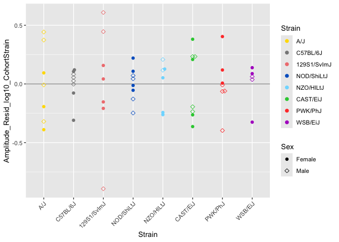

```r
fibroblast_amplitude_resid$Amplitude_Resid_log10_CohortStrain = resid(lm(log10(Amplitude_Mean) ~ Cohort + Strain, data = fibroblast_amplitude_resid))

ggplot(data = fibroblast_amplitude_resid, aes(x = Strain, y = Amplitude_Resid_log10_CohortStrain, color = Strain, shape = Sex)) +
  geom_hline(yintercept = 0, col = "#999999") +
  geom_beeswarm(size = 2) +
  scale_color_manual(values = founders_key$collaborative_cross_color_broman) +
  theme(axis.text.x = element_text(angle = 45, hjust = 1)) +
  scale_shape_manual(values = c(16,23))
```

This model has a good fit. Showing ANOVA table for this model.

```r
anova(lm(log10(Amplitude_Mean) ~ Cohort + Strain, data = fibroblast_amplitude_resid))
```

|  | Df | Sum Sq | Mean Sq | F value | Pr(>F) |
| --- | --- | --- | --- | --- | --- |
| Cohort | 1 | 0.4839538 | 0.48395376 | 6.213524 | 1.625899e-02 |
| Strain | 7 | 4.7205634 | 0.67436620 | 8.658245 | 8.728513e-07 |
| Residuals | 47 | 3.6606968 | 0.07788717 | NA | NA |

This will be used for downstream heritability calculations. However, also fitting overall model with strain, sex, and their interactions:

```r
anova(lm(log10(Amplitude_Mean) ~ Cohort + Strain + Sex + Strain:Sex, data = fibroblast_amplitude_resid))
```

|  | Df | Sum Sq | Mean Sq | F value | Pr(>F) |
| --- | --- | --- | --- | --- | --- |
| Cohort | 1 | 0.48395376 | 0.48395376 | 5.8860122 | 1.998717e-02 |
| Strain | 7 | 4.72056338 | 0.67436620 | 8.2018738 | 4.024826e-06 |
| Sex | 1 | 0.01696894 | 0.01696894 | 0.2063821 | 6.521364e-01 |
| Strain:Sex | 7 | 0.43710921 | 0.06244417 | 0.7594675 | 6.241191e-01 |
| Residuals | 39 | 3.20661867 | 0.08222099 | NA | NA |

### 2.3.2 Calculating heritability for fibroblast data

Calculating heritability using the ANOVA table from the best fitting model. Using the following equation:

$h^2=\displaystyle{{MS_{strain}-MS_{resid}}\over{MS_{strain} + (n_{mean} - 1) * MS_{resid}}}$

where $MS_{strain}$ is the mean square of the strain differences, $MS_{resid}$ is the mean square of the residuals, and $n_{mean}$ is the mean sample size of a strain.

```r
h2_strainanova <- function(msgenetics, mserror, n) {
  return((msgenetics - mserror) / (msgenetics + (n - 1) * mserror))
}

mean_n = nrow(fibroblast_amplitude_mean) / length(unique(fibroblast_amplitude_mean$Strain))
anova_amplitude = anova(lm(log10(Amplitude_Mean) ~ Cohort + Strain, data = fibroblast_amplitude_mean))
anova_amplitude_df = as.data.frame(anova_amplitude)
h2_amplitude = h2_strainanova(anova_amplitude_df["Strain","Mean Sq"],
                              anova_amplitude_df["Residuals","Mean Sq"],
                              mean_n)
h2_amplitude
```

```
## [1] 0.5224531
```

### 2.3.3 Plotting strain x sex means

Plotting the strain:sex information for these data.

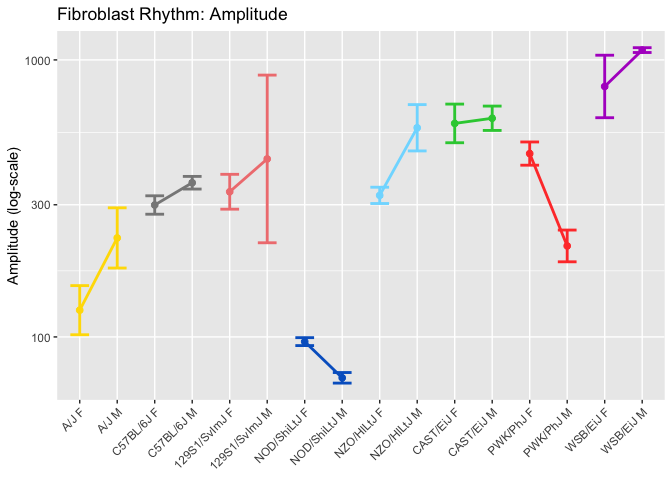

```r
fibroblast_plotting_summary = fibroblast_amplitude_mean %>%
  group_by(Strain, Sex) %>%
  summarize(Strain_Sex_mean = mean(log10(Amplitude_Mean), na.rm = TRUE),
            Strain_Sex_sem = sd(log10(Amplitude_Mean), na.rm = TRUE) / length(which(!is.na(log10(Amplitude_Mean))))) %>%
  mutate(Strain_Sex = paste(Strain, gsub("^([MF]).*$", "\\1", Sex), sep = " "),
         Strain_Sex_backmean = 10^Strain_Sex_mean,
         Strain_Sex_ul = 10^(Strain_Sex_mean + Strain_Sex_sem),
         Strain_Sex_ll = 10^(Strain_Sex_mean - Strain_Sex_sem))
fibroblast_plotting_summary = as.data.frame(fibroblast_plotting_summary)
fibroblast_plotting_summary$Strain_Sex = factor(fibroblast_plotting_summary$Strain_Sex,
                                                levels = paste(rep(founders_key$strain, each = 2), rep(c(" F", " M"), times = 8), sep = ""),
                                                ordered = TRUE)
fibroblast_plotting_summary$Strain = factor(fibroblast_plotting_summary$Strain,
                                            levels = founders_key$strain,
                                            ordered = TRUE)

founders_amplitude_strain_sex_plot = ggplot(data = fibroblast_plotting_summary, aes(x = Strain_Sex, y = Strain_Sex_backmean, color = Strain, group = Strain)) +
  geom_line(size = 1) +
  geom_point(size = 2) +
  geom_errorbar(aes(ymin = Strain_Sex_ll, ymax = Strain_Sex_ul), width = 0.5, size = 1) +
  scale_color_manual(values = founders_key$collaborative_cross_color_broman) +
  theme(axis.text.x = element_text(angle = 45, hjust = 1), legend.position="none") +
  xlab(NULL) +
  ylab("Amplitude (log-scale)") +
  scale_y_log10() +
  ggtitle("Fibroblast Rhythm: Amplitude")
founders_amplitude_strain_sex_plot
```

Showing individual points in a beeswarm plot as well.

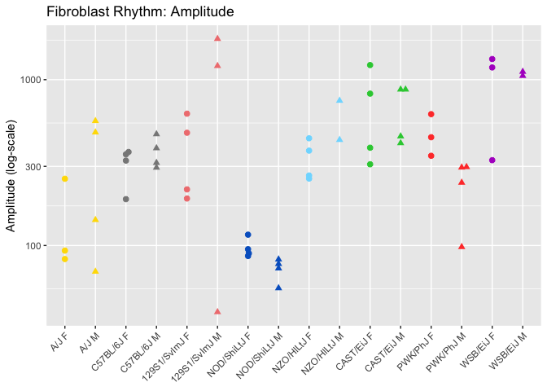

```r
fibroblast_amplitude_mean$Strain_Sex = factor(paste(as.character(fibroblast_amplitude_mean$Strain),
                                                    gsub("^([MF]).*$","\\1",as.character(fibroblast_amplitude_mean$Sex)),
                                                    sep = " "),
                                              levels = paste(rep(founders_key$strain, each = 2), rep(c("F","M"), times = 8), sep = " "),
                                              ordered = TRUE)
fibroblast_amplitude_mean$Strain = factor(fibroblast_amplitude_mean$Strain, levels = founders_key$strain, ordered = TRUE)
founders_amplitude_individual_points_plot = ggplot(data = fibroblast_amplitude_mean, aes(x = Strain_Sex, y = Amplitude_Mean, color = Strain, shape = Sex)) +
  geom_beeswarm(size = 2) +
  scale_color_manual(values = c(founders_key$collaborative_cross_color_broman)) +
  scale_y_log10() +
  scale_shape_manual(values = c(19,17)) +
  theme(axis.text.x = element_text(angle = 45, hjust = 1), legend.position="none") +
  xlab(NULL) +
  ylab("Amplitude (log-scale)") +
  ggtitle("Fibroblast Rhythm: Amplitude")
founders_amplitude_individual_points_plot
```

Saving plot

```r
saveRDS(founders_amplitude_strain_sex_plot, "./output/founders_amplitude_strain_sex_plot.RDS")
```

# 3 Reproducibility Information

## 3.1 Software Used

### 3.1.1 R session and OS information

```r
circadian_fibroblast_sessionInfo
```

[output not shown]

```r
saveRDS(circadian_fibroblast_sessionInfo, paste(script_root_dir, "./output/circadian_fibroblast_sessionInfo_",current_date,".RDS", sep = ""), compress="xz")
```

## 3.2 Document Control

This document was prepared using RMarkdown in RStudio.